# Watson na Saúde

# Contexto

- IBM Watson venceu Jeopardy em 2011

[figure not shown]

- Usando Processamento de Linguagem Natural PROFUNDA (com contexto) e acesso a conteúdo da Internet (High 2012)
- A IBM resolveu investir na medicina por IA em 2014

# Problema

- A escolha de tratamento de câncer é complexa (Puglielli et al. 2018):
  - Efetividade depende das características do paciente e da doença
  - É muito difícil saber se a escolha foi correta
  - A literatura é muito vasta
- Quanto à literatura (Chen, Jd, and Weber 2016):
  - 200.000 experimentos com 21.000 novos medicamentos ativos
  - Existem 24 milhões de artigos de medicina publicados. 1,8 milhão é publicado anualmente
  - O número de novos artigos científicos publicados dobra a cada 9 anos

# Teoria

Usando Processamento de Linguagem Natural Profunda e até mesmo reconhecimento diagramas químicos, é possível chegar a possíveis tratamentos, que podem ser ranqueados quanto à sua efetividade para um paciente específico (Chen, Jd, and Weber 2016), de forma mais eficiente do que uma junta médica.

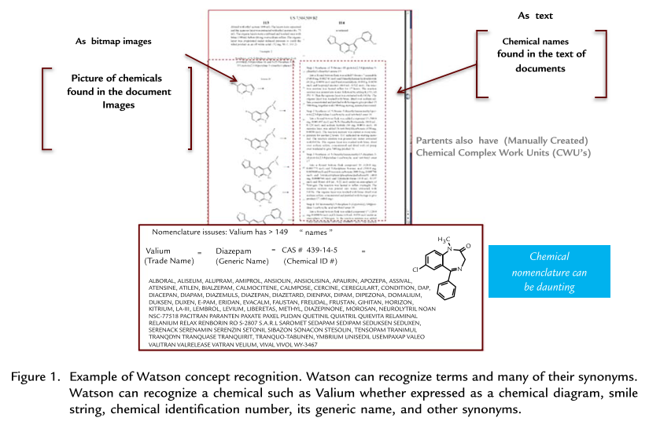

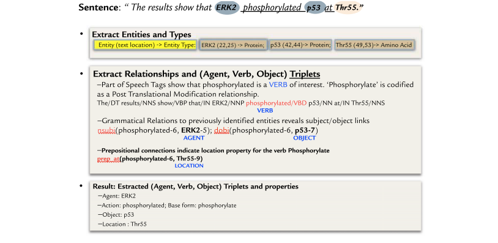

# Experimento

- IBM Watson está em experiência em vários lugares, mas em nenhum ele está “em produção” ainda.
- Os artigos avaliam a taxa de concordância entre o IBM Watson e uma junta médica
  - A maioria dos artigos aponta uma taxa de concordância alta, chegando a 93% (Somashekhar et al. 2018) (Atieh Graham et al. 2018)
  - Alguns artigos mostram taxas variáveis por tipo de câncer, e concluem que Watson ainda não está maduro para substituir médicos humanos (Lee et al. 2018) (Zhou et al. 2019)
- Todos os artigos jornalísticos encontrados fazem críticas ao IBM Watson, relatando que em nenhum caso ele está em produção e que em alguns casos ele gerou decisões de tratamento injustificáveis e claramente erradas.
  - O mais completo deles (Strickland 2019) mostra uma lista de lugares onde o Watson foi testado. Em alguns ele foi descontinuado e em outros continua em testes, mas em apenas em um ele é usado de verdade.
  - Em alguns lugares houve resultados melhores com o Watson for Genomics, que usa informação estruturada (genoma) ao invés dos prontuários. Há dificuldade em se entender os dados dos prontuários dos pacientes.

# Discussões

- Ambiente Kind x Wicked
  - Gary Klein sempre estudou como a intuição de especialistas melhora com o tempo
  - Daniel Kahneman sempre executou experimentos onde as intuições se mostravam falhas (mesmo para especialistas)
  - Em um artigo em conjunto (Kahneman and Klein 2009), eles concluem que não há discordância: o tipo de ambiente onde se dá a decisão que faz o uso da intuição ser mais difícil. As definições de ambientes Kind e Wicked vêm de um livro de Hogarth (Hogarth 2001).
- Questões comerciais. Trade-off lançar logo x lançar maduro.
  - A IBM saiu ganhando?
  - Entrar numa empreitada dessas é arriscado. Como financiar? Governo?
- Tolerância para erros de IA menor que erros humanos?
  - Por que aceitamos tantas mortes por motoristas humanos mas nos escandalizamos com uma morte por um carro autônomo?
  - Quem deveria assumir a responsabilidade?
  - O racional por trás das decisões por IA é menos transparente. Como melhorar isso?

# Referências

Atieh Graham, D M, D M McNamara, S E Waintraub, S L Goldberg, A D Norden, J Hervey, A L Pecora, et al. 2018. “1589PAre treatment recommendations provided by cognitive computing supported by real world data (Watson for Oncology with Cota RWE) concordant with expert opinions?” *Annals of Oncology* 29 (October). https://doi.org/10.1093/annonc/mdy297.031.

Chen, Ying, Elenee Argentinis Jd, and Griff Weber. 2016. “Review Article IBM Watson : How Cognitive Computing Can Be Applied to Big Data Challenges in Life Sciences Research” 38 (4): 688–701. https://doi.org/10.1016/j.clinthera.2015.12.001.

High, Rob. 2012. “The Era of Cognitive Systems: An Inside Look at Ibm Watson and How It Works.” *IBM Corporation, Redbooks*.

Hogarth, Robin M. 2001. *Educating Intuition*. University of Chicago Press.

Kahneman, Daniel, and Gary Klein. 2009. “Conditions for Intuitive Expertise: A Failure to Disagree.” *American Psychologist* 64 (6): 515.

Lee, Won-Suk, Sung Min Ahn, Jun-Won Chung, Kyoung Oh Kim, Kwang An Kwon, Yoonjae Kim, Sunjin Sym, et al. 2018. “Assessing Concordance with Watson for Oncology, a Cognitive Computing Decision Support System for Colon Cancer Treatment in Korea.” *JCO Clinical Cancer Informatics* 2: 1–8.

Puglielli, S, A D Norden, E H Shortliffe, C Rohit Kumar, A Rauthan, N Arun Kumar, P Patil, K Rhee, and Y Ramya. 2018. “Watson for Oncology and breast cancer treatment recommendations : agreement with an expert multidisciplinary tumor board Original article,” no. January: 418–23. https://doi.org/10.1093/annonc/mdx781.

Somashekhar, S P, M -J Sepúlveda, S Puglielli, A D Norden, E H Shortliffe, C Rohit Kumar, A Rauthan, et al. 2018. “Watson for Oncology and breast cancer treatment recommendations: agreement with an expert multidisciplinary tumor board.” *Annals of Oncology* 29 (2): 418–23. https://doi.org/10.1093/annonc/mdx781.

Strickland, Eliza. 2019. “IBM Watson, Heal Thyself: How Ibm Overpromised and Underdelivered on Ai Health Care.” *IEEE Spectrum* 56 (4): 24–31.

Zhou, Na, Chuan-Tao Zhang, Hong-Ying Lv, Chen-Xing Hao, Tian-Jun Li, Jing-Juan Zhu, Hua Zhu, et al. 2019. “Concordance Study Between Ibm Watson for Oncology and Clinical Practice for Patients with Cancer in China.” *The Oncologist* 24 (6): 812–19.